# Getting Data From an Api

## Objetivo

1. Aprender a utilizar algunas funciones de las siguientes librerias
   1. `httr`
   2. `jsonlite`
   3. `purrr`
2. Hacer un **POST** y un **GET** request a un api.
3. Conectarse al API de spotify
4. Manejar listas

## Spotify api

[figure not shown]

Spotify es un servicio de música, podcasts y vídeos digitales en streaming que te da acceso a millones de canciones y otros contenidos de artistas de todo el mundo.

### Crear una cuenta

Ingresar a https://developer.spotify.com/ si o se tiene cuenta crear una.

### Crear una nueva app

#### Step 0

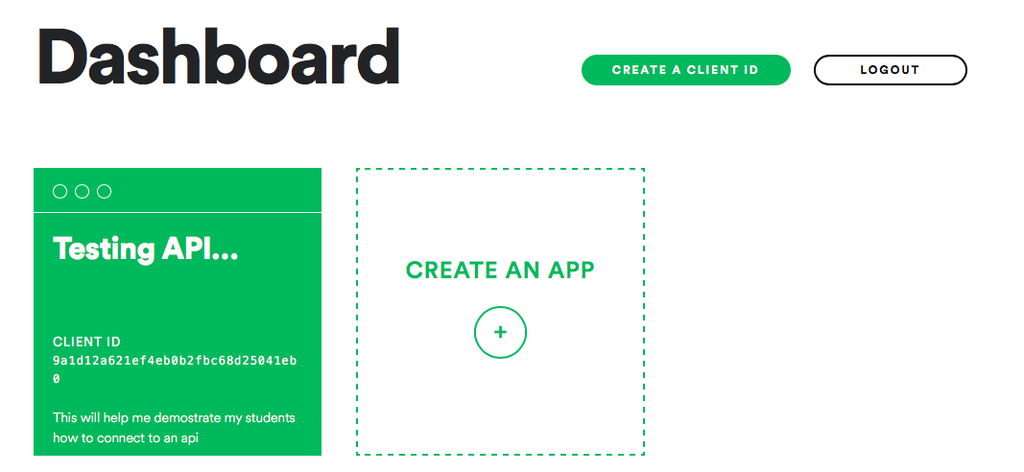

#### Step 1

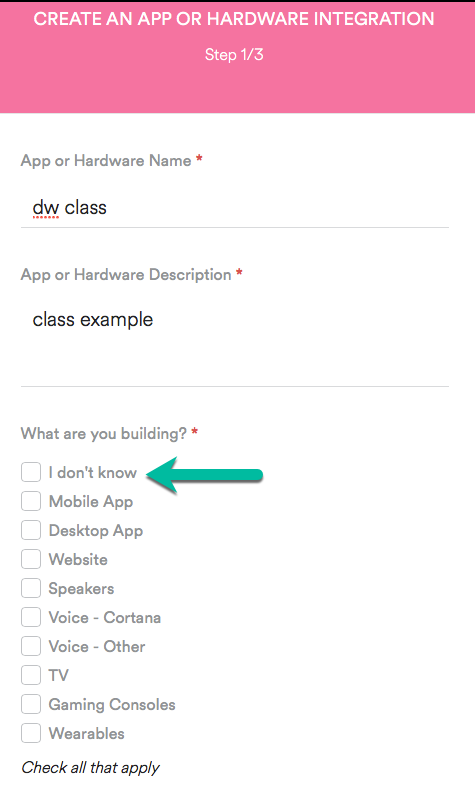

#### Step 2

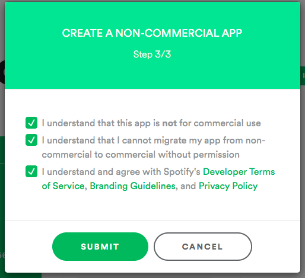

#### App ready

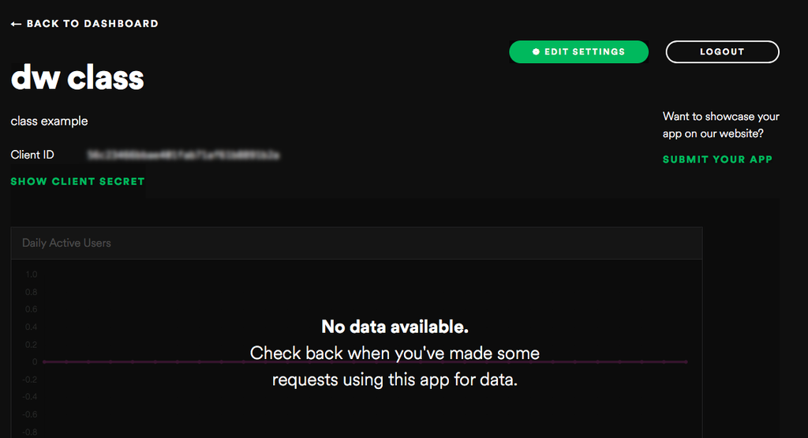

#### Get Client ID and Client Secret

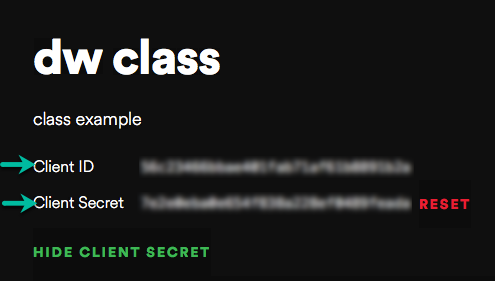

## Obtener data del api

https://developer.spotify.com/documentation/web-api/reference/

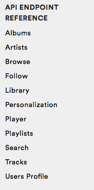

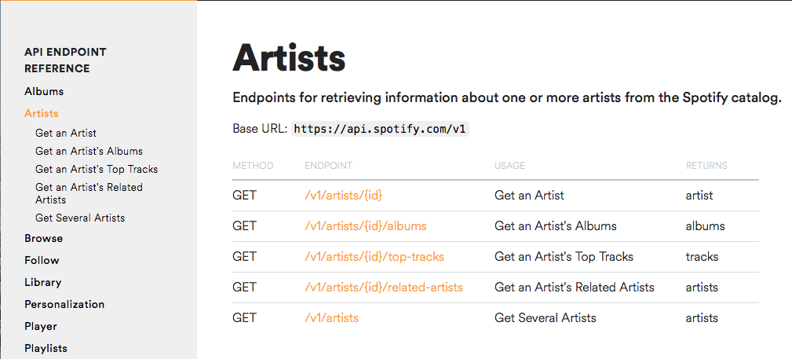

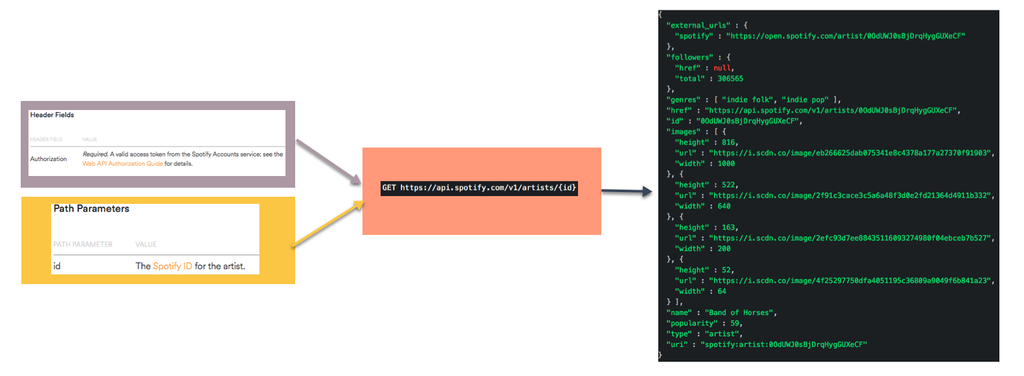

La clave esta en poder tener un codigo de autenticacion, sin este codigo no podemos hace nuestras consultas al api. Para probarlos hagamos click en el siguietne boton

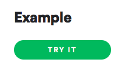

Nos lleva a esta pantalla

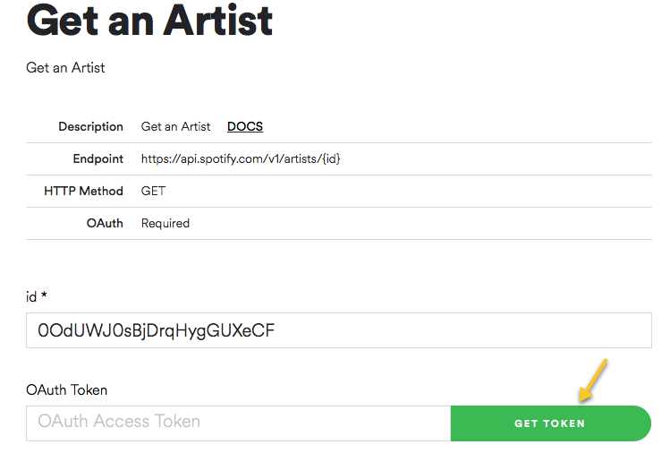

Clicks en ese boton y nos genera nuestro token de autorizacion.

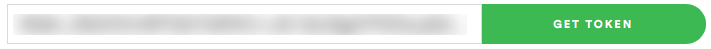

Para armar el request usaremos el programa PostMan

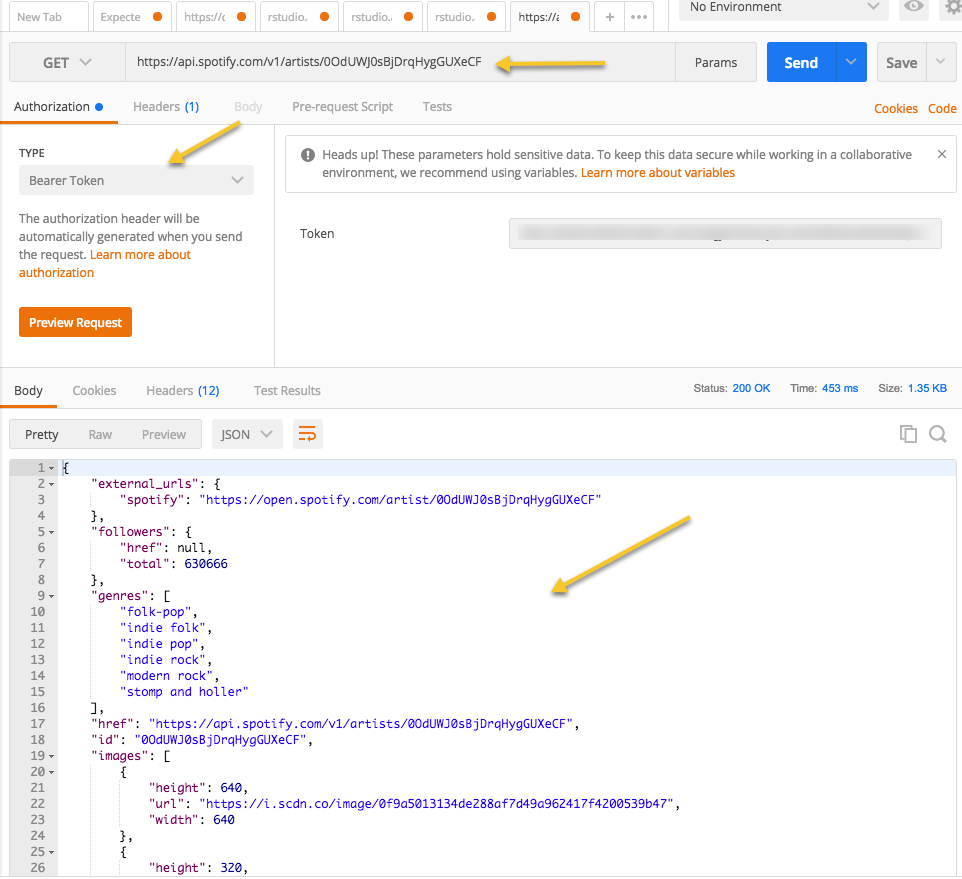

Ejercicio: Armemos un request con postman para hacer un search.

paso 1: https://developer.spotify.com/documentation/web-api/reference/search/search/ paso 2: Hacemos el llamado desde postman

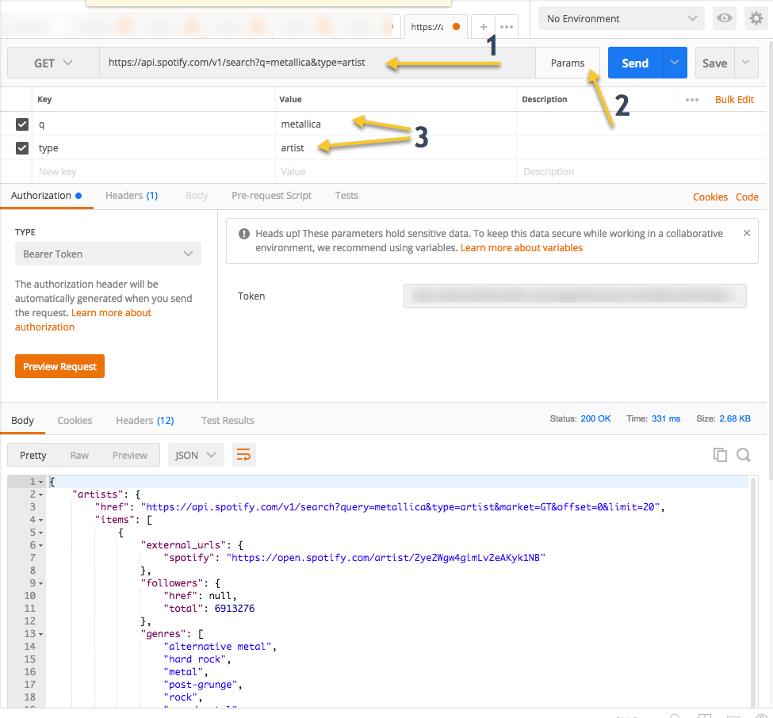

So far, so god. Ahora como lo hacemos programaticamente.

## Calling spotify api from R

### Getting the token

Necesitaremos cargar las siguientes librerias

```r
library(httr)
library(curl)
library(jsonlite)
library(purrr)
```

Antes vamos a crear variables de entorno para nuestro `cliente_id` y `client_secret` es buena practica no dejar en el codigo usuraios y contraseñas.

```r
Sys.setenv(CLIENT_ID="123abc",
           CLIENT_SECRET = "123abc")
```

Revisemos la documentacion, https://developer.spotify.com/documentation/general/guides/authorization-guide/

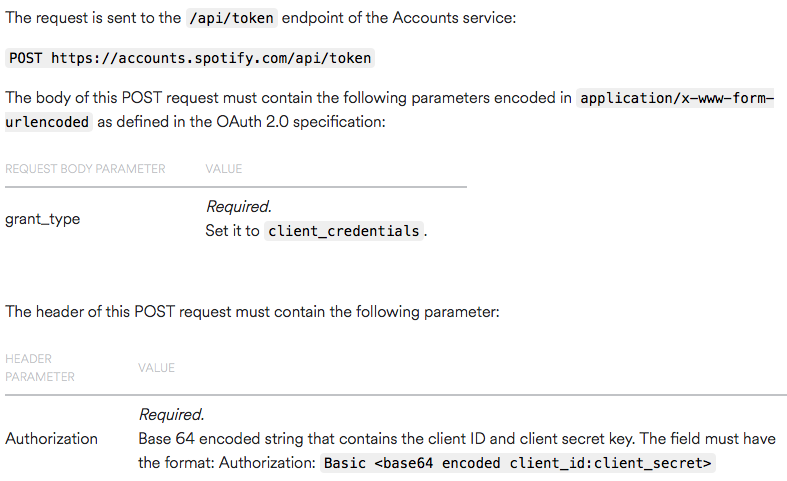

Nuestro primer paso es armar el string que requiere `Authorization` tiene que tenes la siguiente forma `Basic client_id:client_secret` luego codificamos el string en base64, en el codigo se muestra paso a paso.

```r
client_id = Sys.getenv("CLIENT_ID")
client_secret = Sys.getenv("CLIENT_SECRET")
auth_str <- paste(client_id,client_secret,sep=':')
id_secret <- RCurl::base64(auth_str)[[1]]
```

Agreguemos esto a los headers de nuestro request,

```r
my_headers <- httr::add_headers(c(Authorization=paste('Basic', id_secret,sep=' ')))
```

Ahora formamos el body del `POST`

```r
my_body <- list(grant_type='client_credentials')
```

Ya esta todo listo para mandar nuestro request,

```r
request <- httr::POST('https://accounts.spotify.com/api/token', my_headers,body=my_body,encode='form')
my_token <- httr::content(request)
str(my_token)
```

```
List of 4
 $ access_token: chr "BQBw6JKAg7j0c4Jbg38SVHKUimtfI1546Ym-lXX9wULrMqQD0TriYsOdlHUdVhlH8QrQ5Du1CmfR8g19k8Q"
 $ token_type  : chr "Bearer"
 $ expires_in  : int 3600
 $ scope       : chr ""
```

Como podemos ver tenemos una lista, en donde el primer elemento es el access_token.

### Lest search for an artist

Ahora estamos lista para buscar la informacion de un artista, revisemos la documentacion para esta endpoint. https://developer.spotify.com/documentation/web-api/reference/search/search/

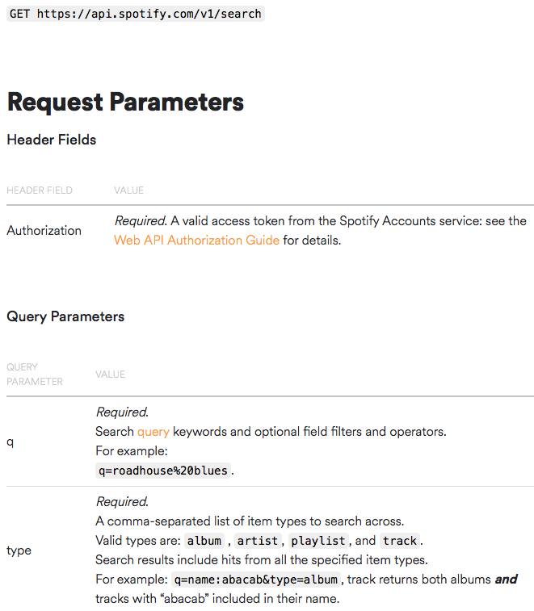

```r
auth_header <- httr::add_headers('Authorization'= paste('Bearer',my_token$access_token))
url <- "https://api.spotify.com/v1/search"
artist <- URLencode("Metallica")
request <- httr::GET(paste(url,'?q=',artist,'&type=artist',sep=''),auth_header)
artist_info <- httr::content(request)
str(artist_info)
```

```
List of 1
 $ artists:List of 7
  ..$ href    : chr "https://api.spotify.com/v1/search?query=Metallica&type=artist&offset=0&limit=20"
  ..$ items   :List of 3
  .. ..$ :List of 10
  .. .. ..$ external_urls:List of 1
  .. .. .. ..$ spotify: chr "https://open.spotify.com/artist/2ye2Wgw4gimLv2eAKyk1NB"
  .. .. ..$ followers    :List of 2
  .. .. .. ..$ href : NULL
  .. .. .. ..$ total: int 6914920
  .. .. ..$ genres       :List of 7
  .. .. .. ..$ : chr "alternative metal"
  .. .. .. ..$ : chr "hard rock"
  .. .. .. ..$ : chr "metal"
  .. .. .. ..$ : chr "post-grunge"
  .. .. .. ..$ : chr "rock"
  .. .. .. ..$ : chr "speed metal"
  .. .. .. ..$ : chr "thrash metal"
  .. .. ..$ href         : chr "https://api.spotify.com/v1/artists/2ye2Wgw4gimLv2eAKyk1NB"
  .. .. ..$ id           : chr "2ye2Wgw4gimLv2eAKyk1NB"
  .. .. ..$ images       :List of 3
  .. .. .. ..$ :List of 3
  .. .. .. .. ..$ height: int 640
  .. .. .. .. ..$ url   : chr "https://i.scdn.co/image/5a06711d7fc48d5e0e3f9a3274ffed3f0af1bd91"
  .. .. .. .. ..$ width : int 640
  .. .. .. ..$ :List of 3
  .. .. .. .. ..$ height: int 320
  .. .. .. .. ..$ url   : chr "https://i.scdn.co/image/0c22030833eb55c14013bb36eb6a429328868c29"
  .. .. .. .. ..$ width : int 320
  .. .. .. ..$ :List of 3
  .. .. .. .. ..$ height: int 160
  .. .. .. .. ..$ url   : chr "https://i.scdn.co/image/c1fb4d88de092b5617e649bd4c406b5cab7d3ddd"
  .. .. .. .. ..$ width : int 160
  .. .. ..$ name         : chr "Metallica"
  .. .. ..$ popularity   : int 82
  .. .. ..$ type         : chr "artist"
  .. .. ..$ uri          : chr "spotify:artist:2ye2Wgw4gimLv2eAKyk1NB"
  .. ..$ :List of 10
  .. .. ..$ external_urls:List of 1
  .. .. .. ..$ spotify: chr "https://open.spotify.com/artist/7xXiZGPcqDEijirJubILoZ"
```

[output cut: 15 more lines]

```
  .. .. .. ..$ href : NULL
  .. .. .. ..$ total: int 172
  .. .. ..$ genres       : list()
  .. .. ..$ href         : chr "https://api.spotify.com/v1/artists/61OPB1XJSYA5JoAvWZUQ4Z"
  .. .. ..$ id           : chr "61OPB1XJSYA5JoAvWZUQ4Z"
  .. .. ..$ images       : list()
  .. .. ..$ name         : chr "Metallica Tribute Band"
  .. .. ..$ popularity   : int 5
  .. .. ..$ type         : chr "artist"
  .. .. ..$ uri          : chr "spotify:artist:61OPB1XJSYA5JoAvWZUQ4Z"
  ..$ limit   : int 20
  ..$ next    : NULL
  ..$ offset  : int 0
  ..$ previous: NULL
  ..$ total   : int 3
```